# Identifying Stellar Flares

**Project Proposal**

Alex Faassen (1005187174)

**Kanban Board/Timeline:** [STA2453 - Project Board](https://voracious-cereal-782.notion.site/1438b211751680248c78eaaaf45572ac?v=4aad22e7653a46b6aa719c4dfa2ed213)

## Question

*"Can we estimate the energy emitted by a flare?"*

As discussed with the class, the stellar flares project intends to better understand these phenomena by learning to (1) identify and then (2) map stellar flares via their brightness (~energy emitted) over time. Ideally, across stars with vastly different characteristics.

**My contribution (term project):** I would like to focus on (1) flare identification. If time permits, I would like to explore the application of previously established (2) flare mapping models to the output of my own mapping model.

**Personal goal:** Learn how to work with time series in practice. Read up on more applicable time series models, be flexible and adapt new ideas to include them when/where possible.

## Data

The provided data comes from the TESS Mission, a survey searching for planets transiting nearby stars. Specifically, this refers to a satellite observing different segments of the hemisphere, ~27 days at a time. The time series of interest is the **Pre-search Data Conditioning SAP (PDCSAP) flux**, which is equivalent to SAP flux with long-term trends, primarily corresponding to measurement error (scattered light), removed. Simple Aperture Photometry (SAP) flux is a measure that aggregates the total brightness (electrons/sec) of every pixel within an image that is identified to be a part of a collective astral object. These observations are taken with a 2-minute cadence. Importantly, flares are not labelled, making this an unsupervised learning setting. Additionally, there are significant gaps in the data due to orbit, technical challenges, etc.

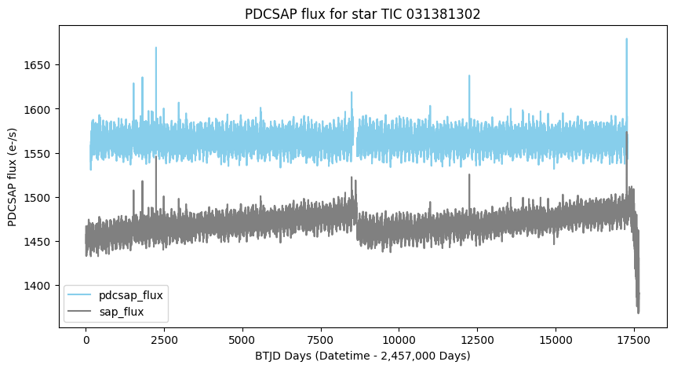

```python
## Plot
from IPython.display import Image
Image("proposalTS.png")
```

## Methods

### Pre-treatment

- Model trends and seasonality (e.g. smoothing, backfitting)

Helpful for removing noise, isolating leftover unidentified trends, such as flares.

### Modelling

- Unsupervised Event Detection: SVM, Isolation Forest, etc.

I've read about Event/Anomaly detection models, they seem well-suited for stellar flare detection. If there is an opportunity to incorporate Deep Learning, it may be a good learning experience.

### Model Evaluation

- Comparison with existing models, e.g. detrending + sigma-clipping, CNN (Neural Networks), etc.

### Model Combinations (if time permits)

- Spectral analysis
- Other publisehd models